# Dataset presentation

The dataset is available at : https://www.kaggle.com/uciml/pima-indians-diabetes-database

This dataset is originally from the National Institute of Diabetes and Digestive and Kidney Diseases.

The objective of the dataset is to diagnostically predict whether or not a patient has diabetes, based on certain diagnostic measurements included in the dataset. Several constraints were placed on the selection of these instances from a larger database. In particular, all patients here are females at least 21 years old of Pima Indian heritage.

The datasets consists of several medical predictor variables and one target variable, Outcome. Predictor variables includes the number of pregnancies the patient has had, their BMI, insulin level, age, and so on.

# Load libraries

```python
import pandas as pd
import seaborn as sns
import matplotlib.pyplot as plt
```

# Load dataset

```python
data = pd.read_csv('diabetes.csv')
```

## Describe the data

```python
data.info()
```

```
<class 'pandas.core.frame.DataFrame'>
RangeIndex: 768 entries, 0 to 767
Data columns (total 9 columns):
 #   Column                    Non-Null Count  Dtype
---  ------                    --------------  -----
 0   Pregnancies               768 non-null    int64
 1   Glucose                   768 non-null    int64
 2   BloodPressure             768 non-null    int64
 3   SkinThickness             768 non-null    int64
 4   Insulin                   768 non-null    int64
 5   BMI                       768 non-null    float64
 6   DiabetesPedigreeFunction  768 non-null    float64
 7   Age                       768 non-null    int64
 8   Outcome                   768 non-null    int64
dtypes: float64(2), int64(7)
memory usage: 54.1 KB
```

As we can see there is 8 inputs and one outputn the column 'Outcome', the dataset is composed of 768 measures. The data as no null values, it seems clean so we can start to analyse the dataset

# Data analysis

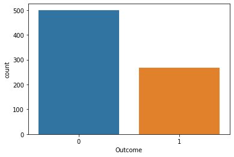

```python
sns.countplot(x='Outcome',data=data)
plt.show()
```

The output values are not equally represented, there is more non-diabete rows.

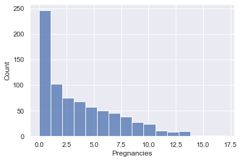

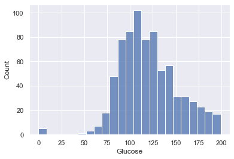

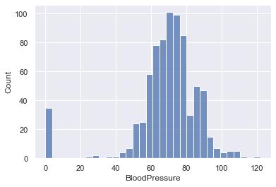

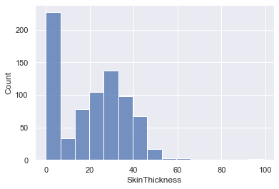

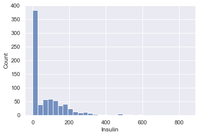

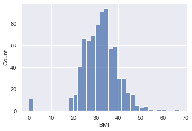

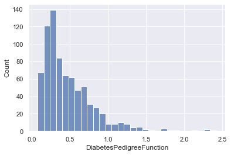

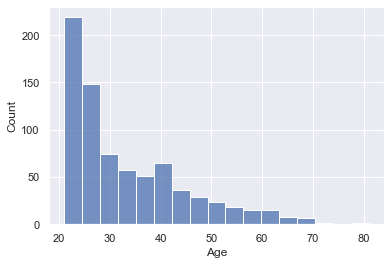

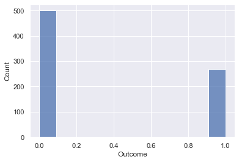

```python
sns.set(color_codes=True)


for col_id in data.columns:
    sns.histplot(data[col_id])
    plt.show()
```

## Same plots but comparing both Outcome 0 and 1

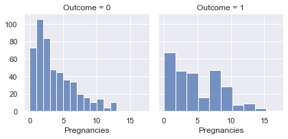

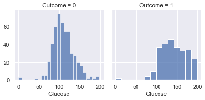

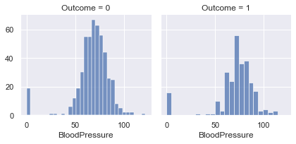

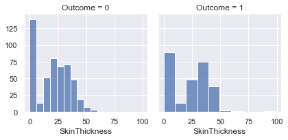

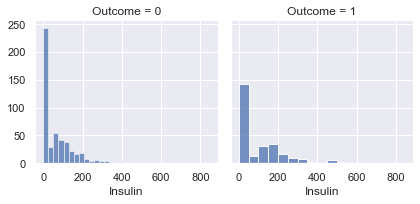

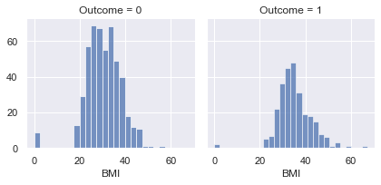

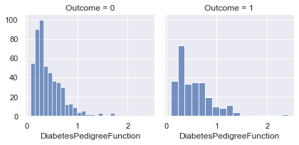

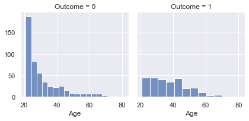

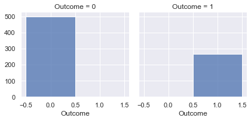

```python
for col_name in data.columns:
    g = sns.FacetGrid(data, col="Outcome")
    g.map(sns.histplot, col_name)
    plt.show()
```

## Analyse the distribution of the features with pairplot

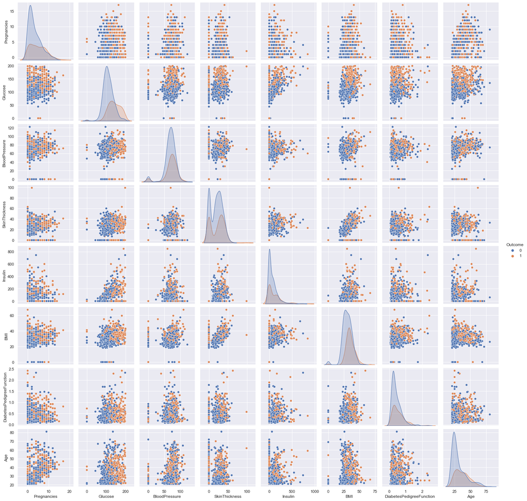

```python
sns.pairplot(data=data,hue='Outcome',diag_kind='kde')
plt.show()
```

What can we see ? (in blue the negative diabete and orange the positive one)

1. The diagonal shows the distribution of the the dataset with the kernel density plots.
2. The scatter-plots shows the relation between each and every attribute or features taken pairwise. Looking at the scatter-plots, we can say that Glucase seems to be an important classification features but no two attributes are able to clearly seperate the two outcome-class instances.

## Corelation between features

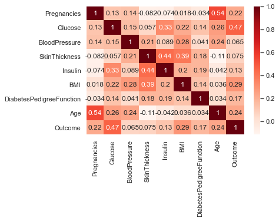

```python
cor = data.corr()
sns.heatmap(cor, annot=True, cmap=plt.cm.Reds)
plt.show()
```

The correlation coefficient has values between -1 to 1

- A value closer to 0 implies weaker correlation (exact 0 implying no correlation)
- A value closer to 1/-1 implies stronger positive/negative correlation

Thus, we want a set of values with low correlation together but a strong one with Outcome

```python
cor_with_Outcome = abs(cor["Outcome"])
cor_with_Outcome.sort_values(ascending=False)
```

```
Outcome                     1.000000
Glucose                     0.466581
BMI                         0.292695
Age                         0.238356
Pregnancies                 0.221898
DiabetesPedigreeFunction    0.173844
Insulin                     0.130548
SkinThickness               0.074752
BloodPressure               0.065068
Name: Outcome, dtype: float64
```

As I thought while looking at the pairplot, Glucose as a strong correlation to the Outcome

But now we can easily see that the SkinThickness and BloodPressure has nearly no influence on the Outcome

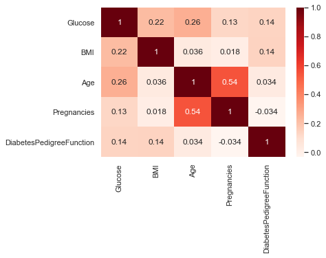

```python
top5_cols = ['Glucose', 'BMI', 'Age', 'Pregnancies', 'DiabetesPedigreeFunction']

top5_cor = data[top5_cols].corr()
sns.heatmap(top5_cor, annot=True, cmap=plt.cm.Reds)
plt.show()
```

As we can see, the Age and the Pregnancies features are quite highly correlated. It might not be wise to use them both together

#### Lets see which one is the most correlated of these 2 with the other top 5 features :

```python
cor_with_Age = abs(top5_cor["Age"])
print('Age total correlation : ', cor_with_Age.sum()-1)

cor_with_Pregnancies = abs(top5_cor["Pregnancies"])
print('Pregnancies total correlation : ', cor_with_Pregnancies.sum()-1)
```

```
Age total correlation :  0.8776587307537722
Pregnancies total correlation :  0.7250056635920556
```

The Age is more correlated to the 'top 5' features than Pregnancies. If we decide to discard one of these two, it should be Age.